# HOMEWORK 04

- Show All Code
- Hide All Code

Author

Nathan Lunceford

# SECTION 2.5

**Assigned:** 15, 19, 23, 29, 37, 41**

**2.5.15**

### Problem:

Solve the differential equation $y' = 10y$.

### Solution:

1. Rewrite the equation:

   $$\frac{dy}{dt} = 10y$$
2. Separate the variables $y$ and $t$:

   $$\frac{1}{y} \, dy = 10 \, dt$$
3. Integrate both sides:

   $$\int \frac{1}{y} \, dy = \int 10 \, dt$$
4. The result of the integration is:

   $$\ln|y| = 10t + C$$
5. Exponentiate both sides to solve for $y$:

   $$|y| = e^{10t + C} = e^C \cdot e^{10t}$$
6. Let $A = e^C$:
   $$y = A e^{10t}$$

**Final Answer:**

The general solution is:
$$y = A e^{10t}$$
where $A$ is the constant of integration.

**2.5.19**

### Problem:

Solve the differential equation $t^2 y' + y^2 = 1$.

### Solution:

1. Rewrite the equation:

   $$t^2 \frac{dy}{dt} + y^2 = 1$$
2. Rearrange the equation to isolate $\frac{dy}{dt}$:

   $$t^2 \frac{dy}{dt} = 1 - y^2$$
3. Separate the variables $y$ and $t$:

   $$\frac{dy}{1 - y^2} = \frac{dt}{t^2}$$
4. Now use partial fraction decomposition on $\frac{1}{1 - y^2}$:

   $$\frac{1}{1 - y^2} = \frac{1}{2} \left( \frac{1}{1 - y} + \frac{1}{1 + y} \right)$$
5. Substitute the partial fraction decomposition back into the equation:

   $$\frac{1}{2} \left( \frac{1}{1 - y} + \frac{1}{1 + y} \right) dy = \frac{dt}{t^2}$$
6. Integrate both sides:
   - Left-hand side:

     $$\frac{1}{2} \left( \int \frac{1}{1 - y} \, dy + \int \frac{1}{1 + y} \, dy \right)
     = \frac{1}{2} \left( -\ln|1 - y| + \ln|1 + y| \right)$$

     Simplifying:

     $$\frac{1}{2} \ln\left|\frac{1 + y}{1 - y}\right|$$
   - Right-hand side:
     $$\int \frac{1}{t^2} \, dt = -\frac{1}{t}$$
7. Combine the integrals:

   $$\frac{1}{2} \ln\left|\frac{1 + y}{1 - y}\right| = -\frac{1}{t} + C$$
8. Multiply through by 2:

   $$\ln\left|\frac{1 + y}{1 - y}\right| = -\frac{2}{t} + 2C$$
9. Exponentiate both sides to remove the logarithm:

   $$\left|\frac{1 + y}{1 - y}\right| = e^{-\frac{2}{t} + 2C}$$
10. Let $A = e^{2C}$, which simplifies the equation to:

    $$\frac{1 + y}{1 - y} = A e^{-\frac{2}{t}}$$
11. Solve for $y$:

    Cross-multiply:

    $$1 + y = (1 - y) A e^{-\frac{2}{t}}$$

    Expand the right-hand side:

    $$1 + y = A e^{-\frac{2}{t}} - A e^{-\frac{2}{t}} y$$

    Now gather terms involving $y$ on one side:

    $$y + A e^{-\frac{2}{t}} y = A e^{-\frac{2}{t}} - 1$$

    Factor out $y$ on the left-hand side:

    $$y(1 + A e^{-\frac{2}{t}}) = A e^{-\frac{2}{t}} - 1$$

    Solve for $y$:

    $$y = \frac{A e^{-\frac{2}{t}} - 1}{1 + A e^{-\frac{2}{t}}}$$

**Final Answer:**

The general solution is:

$$y = \frac{A e^{-\frac{2}{t}} - 1}{1 + A e^{-\frac{2}{t}}}$$

where $A$ is the constant of integration.

**2.5.23**

### Problem:

Solve the differential equation:

$$y - t \frac{dy}{dt} = 6 - 3t^2 \frac{dy}{dt}$$

### Solution:

1. **Rearrange the equation:**

   Start by moving all terms involving $\frac{dy}{dt}$ to one side:

   $$y - t \frac{dy}{dt} = 6 - 3t^2 \frac{dy}{dt}$$

   Rearranging the terms involving $\frac{dy}{dt}$:

   $$y = 6 + \frac{dy}{dt} \left( 3t^2 - t \right)$$
2. **Solve for $\frac{dy}{dt}$:**

   Isolate $\frac{dy}{dt}$:

   $$y - 6 = \frac{dy}{dt} (3t^2 - t)$$

   Now, solve for $\frac{dy}{dt}$:

   $$\frac{dy}{dt} = \frac{y - 6}{3t^2 - t}$$
3. **Separate the variables:**

   Separate the variables $y$ and $t$:

   $$\frac{dy}{y - 6} = \frac{dt}{t(1 - 3t)}$$
4. **Integrate both sides:**

   Now we will integrate both sides:
   - The left-hand side:

     $$\int \frac{1}{y - 6} \, dy = \ln|y - 6|$$
   - The right-hand side can be handled by using partial fraction decomposition on $\frac{1}{t(1 - 3t)}$:

     We decompose:

     $$\frac{1}{t(1 - 3t)} = \frac{A}{t} + \frac{B}{1 - 3t}$$

     Multiply both sides by $t(1 - 3t)$:

     $$1 = A(1 - 3t) + Bt$$

     Expand:

     $$1 = A - 3At + Bt$$

     Group terms involving $t$:

     $$1 = A + t(B - 3A)$$

     Equating coefficients gives the system:

     $$A = 1 \quad \text{and} \quad B - 3A = 0$$

     From $A = 1$, we have $B = 3$.

     The partial fraction decomposition is:

     $$\frac{1}{t(1 - 3t)} = \frac{1}{t} + \frac{3}{1 - 3t}$$

     Now integrate both terms:

     $$\int \frac{1}{t} \, dt + \int \frac{3}{1 - 3t} \, dt = \ln|t| - \ln|1 - 3t|$$
5. **Combine the integrals:**

   Combine the results from both sides:

   $$\ln|y - 6| = \ln|t| - \ln|1 - 3t| + C$$
6. **Simplify the logarithms:**

   Simplify the right-hand side using properties of logarithms:

   $$\ln|y - 6| = \ln\left|\frac{t}{1 - 3t}\right| + C$$

   Exponentiate both sides to remove the logarithms:

   $$|y - 6| = e^C \left|\frac{t}{1 - 3t}\right|$$

   Let $A = e^C$, so:

   $$y - 6 = A \frac{t}{1 - 3t}$$
7. **Solve for $y$:**

   $$y = 6 + A \frac{t}{1 - 3t}$$

**Final Answer:**

The solution to the differential equation is:

$$y = 6 + A \frac{t}{1 - 3t}$$

where $A$ is the constant of integration.

**2.5.29**

### Problem:

Solve the initial value problem $y' = 10y$, with the initial condition $y(0) = 3$.

### Solution:

We know from **Problem 2.5.15** that the general solution to the differential equation $y' = 10y$ is:

$$y = A e^{10t}$$

1. Use the initial condition $y(0) = 3$ to find $A$:

   $$y(0) = A e^{10 \cdot 0} = A = 3$$

   Therefore, $A = 3$.
2. The particular solution is:
   $$y = 3 e^{10t}$$

#### Plotting the Direction Field and Solution:

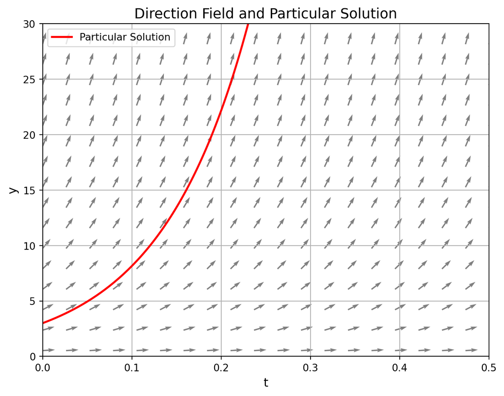

```python
import numpy as np
import matplotlib.pyplot as plt

# Define the differential equation dy/dt = 10y
def dydt(t, y):
    return 10 * y

# Generate grid for direction field
t = np.linspace(0, 0.5, 20)
y = np.linspace(-5, 30, 20)
T, Y = np.meshgrid(t, y)

# Calculate slope for direction field
slope = dydt(T, Y)

# Normalize the direction field arrows
norm = np.sqrt(1 + slope**2)
T_dir = 1 / norm
Y_dir = slope / norm

# Plot the direction field
plt.figure(figsize=(8, 6))
plt.quiver(T, Y, T_dir, Y_dir, angles="xy", color="gray")

# Plot the solution curve
t_vals = np.linspace(0, 0.5, 200)
y_vals = 3 * np.exp(10 * t_vals)

plt.plot(t_vals, y_vals, 'r', linewidth=2, label="Particular Solution")

# Add labels, title, and limits
plt.title("Direction Field and Particular Solution", fontsize=14)
plt.xlabel("t", fontsize=12)
plt.ylabel("y", fontsize=12)
plt.xlim([0, 0.5])
plt.ylim([0, 30])

# Add grid and legend
plt.grid(True)
plt.legend(loc="upper left")

# Display the plot
plt.show()
```

**Final Answer:**

The solution to the initial value problem is:

$$y = 3 e^{10t}$$

This solution represents exponential growth with an initial value of 3 at $t = 0$, as reflected in the direction field and solution curve plot.

**2.5.37**

### Problem:

Solve the initial value problem:

$$y - t \frac{dy}{dt} = 6 - 3t^2 \frac{dy}{dt}, \quad y(1) = 5$$

### Solution:

We know from **Problem 2.5.23** that the general solution to this differential equation is:

$$y = 6 + A \frac{t}{1 - 3t}$$

Use the initial condition $y(1) = 5$ to find the value of $A$.

1. **Substitute the initial condition $t = 1$ and $y = 5$ into the general solution:**

   $$5 = 6 + A \frac{1}{1 - 3 \cdot 1}$$
2. **Simplify the equation:**

   $$5 = 6 + A \frac{1}{-2}$$

   This simplifies to:

   $$5 = 6 - \frac{A}{2}$$
3. **Solve for $A$:**

   Subtract 6 from both sides:

   $$-1 = -\frac{A}{2}$$

   Multiply both sides by -2:

   $$A = 2$$
4. **Substitute $A = 2$ into the general solution:**
   $$y = 6 + 2 \frac{t}{1 - 3t}$$

The particular solution to the initial value problem is:

$$y = 6 + \frac{2t}{1 - 3t}$$

#### Plotting the Direction Field and Solution:

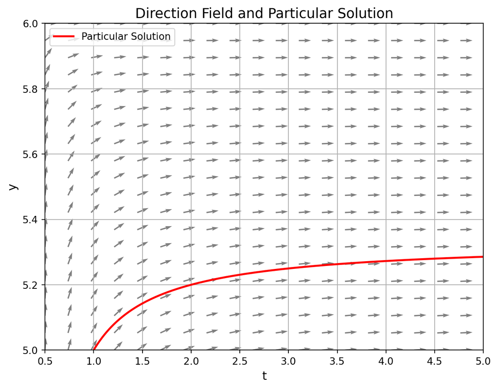

```python
# Define the differential equation dy/dt = (y - 6) / (t - 3t^2)
def dydt(t, y):
    return (y - 6) / (t - (3 * t**2))

# Generate grid for direction field
t = np.linspace(0.5, 5, 20)
y = np.linspace(5, 6, 20)
T, Y = np.meshgrid(t, y)

# Calculate slope for direction field
slope = dydt(T, Y)

# Normalize the direction field arrows
norm = np.sqrt(1 + slope**2)
T_dir = 1 / norm
Y_dir = slope / norm

# Plot the direction field
plt.figure(figsize=(8, 6))
plt.quiver(T, Y, T_dir, Y_dir, angles="xy", color="gray")

# Plot the particular solution curve y = 6 + 2t / (1 - 3t)
t_vals = np.linspace(0.5, 5, 200)
y_vals = 6 + ((2 * t_vals) / (1 - 3 * t_vals))

plt.plot(t_vals, y_vals, 'r', linewidth=2, label="Particular Solution")

# Add labels, title, and limits
plt.title("Direction Field and Particular Solution", fontsize=14)
plt.xlabel("t", fontsize=12)
plt.ylabel("y", fontsize=12)
plt.xlim([0.5, 5])
plt.ylim([5, 6])

# Add grid and legend
plt.grid(True)
plt.legend(loc="upper left")

# Display the plot
plt.show()
```

**Final Answer:**

The solution to the initial value problem is:

$$y = 6 + \frac{2t}{1 - 3t}$$

**2.5.41**

### Problem:

Solve the initial value problem:

$$(y + t) y' + y = t, \quad y(0) = 1$$

with the initial condition $y(0) = 1$, and then plot an appropriate direction field and sketch your solution.

### Solution:

#### Rearrange the equation

The given equation is:

$$(y + t) \frac{dy}{dt} + y = t$$

Rewrite it as:

$$\frac{dy}{dt} = \frac{t - y}{y + t}$$

Cross multiply:

$$(t-y)dt = (y+t)dy$$

This can be rewritten as:

$$(y - t) dt + (y + t) dy = 0$$

Which is now in the standard form of an exact equation:

$$M(t, y) dt + N(t, y) dy = 0$$

#### Identify $M(t, y)$ and $N(t, y)$

From the rewritten form of the equation:

$$(y - t) dt + (y + t) dy = 0$$

we can identify the functions $M(t, y)$ and $N(t, y)$ as:

$$M(t, y) = y - t \quad \text{and} \quad N(t, y) = y + t$$

#### Test for exactness

To check if the equation is exact, verify the condition for exactness:

$$\frac{\partial M}{\partial y} = \frac{\partial N}{\partial t}$$

Compute the partial derivatives:

- $M(t, y) = y - t$, so $\frac{\partial M}{\partial y} = 1$
- $N(t, y) = y + t$, so $\frac{\partial N}{\partial t} = 1$

Since $\frac{\partial M}{\partial y} = \frac{\partial N}{\partial t}$, the equation is exact.

#### Find the potential function

Since the equation is exact, there exists a potential function $\Phi(t, y)$ such that:

$$\frac{\partial \Phi}{\partial t} = M(t, y) = y - t
\quad \text{and} \quad
\frac{\partial \Phi}{\partial y} = N(t, y) = y + t$$

##### Integrate $M(t, y)$ with respect to $t$

Integrate $M(t, y) = y - t$ with respect to $t$:

$$\Phi(t, y) = \int (y - t) \, dt = yt - \frac{t^2}{2} + h(y)$$

where $h(y)$ is a function of $y$ only.

##### Differentiate $\Phi(t, y)$ with respect to $y$

Differentiate $\Phi(t, y)$ with respect to $y$ and set it equal to $N(t, y) = y + t$:

$$\frac{\partial \Phi}{\partial y} = t + h'(y) = y + t$$

Simplifying:

$$h'(y) = y$$

##### Integrate $h'(y)$

Integrating $h'(y) = y$ with respect to $y$:

$$h(y) = \frac{y^2}{2} + C$$

The potential function is:

$$\Phi(t, y) = yt - \frac{t^2}{2} + \frac{y^2}{2} + C$$

#### General solution

The general solution of an exact differential equation is obtained by setting the potential function $\Phi(t, y)$ equal to a constant:

$$yt - \frac{t^2}{2} + \frac{y^2}{2} = K$$

#### Apply the initial condition

We are given $y(0) = 1$. Substituting $t = 0$ and $y = 1$ into the equation:

$$1(0) - \frac{0^2}{2} + \frac{1^2}{2} = K$$

$$K = \frac{1}{2}$$

#### Final implicit solution

Substitute $K = \frac{1}{2}$ back into the equation:

$$yt - \frac{t^2}{2} + \frac{y^2}{2} = \frac{1}{2}$$

Multiply through by 2 to simplify:

$$2yt - t^2 + y^2 = 1$$

This is the implicit solution of the differential equation:

$$2yt - t^2 + y^2 = 1$$

#### Solve for $y$ using the quadratic formula

Solve this quadratic equation for $y$. Rearrange the equation:

$$y^2 + 2ty + (- t^2 - 1) = 0$$

This is a quadratic equation of the form $ay^2 + by + c = 0$, where:

- $a = 1$
- $b = 2t$
- $c = - t^2 - 1$

Use the quadratic formula to solve for $y$:

$$y = \frac{-b \pm \sqrt{b^2 - 4ac}}{2a}$$

Substitute the values of $a$, $b$, and $c$:

$$y = \frac{-2t \pm \sqrt{(2t)^2 - 4(1)(- t^2 - 1)}}{2}$$

Simplifying:

$$y = \frac{-2t \pm \sqrt{4t^2 - 4(- t^2 - 1)}}{2}$$

$$y = \frac{-2t \pm \sqrt{4t^2 + 4 + 4t^2}}{2}$$

$$y = \frac{-2t \pm \sqrt{8t^2 + 4}}{2}$$

Factor out 4 from inside the square root:

$$y = \frac{-2t \pm \sqrt{4(2t^2 + 1)}}{2}$$

$$y = \frac{-2t \pm 2\sqrt{2t^2 + 1}}{2}$$

$$y = -t \pm \sqrt{2t^2 + 1}$$

#### Apply the initial condition

We are given $y(0) = 1$. Substituting $t = 0$ into the equation:

$$1 = -0 \pm \sqrt{2(0)^2 - 1}$$

$$1 = \pm \sqrt{1}$$

$$1 \ne -1$$

#### Plotting the Direction Field and Solution:

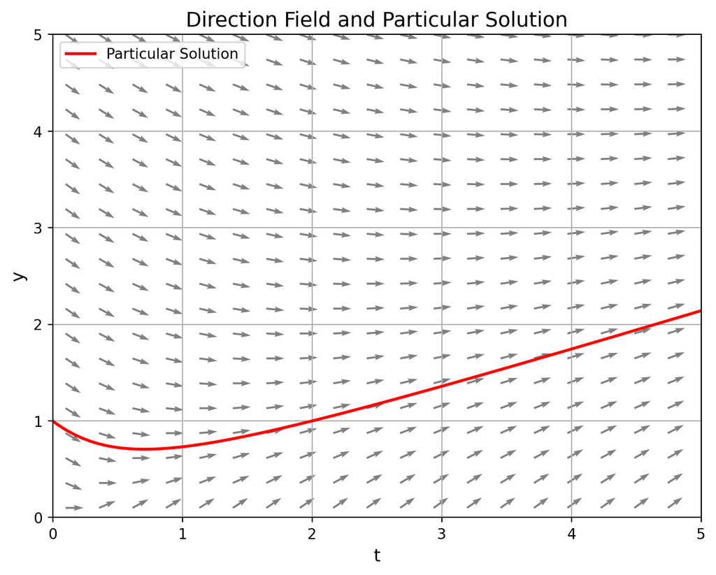

```python
# Define the differential equation dy/dt = (t - y) / (y + t)
def dydt(t, y):
    return (t - y) / (y + t)

# Generate grid for direction field
t = np.linspace(0.1, 5, 20)
y = np.linspace(0.1, 5, 20)
T, Y = np.meshgrid(t, y)

# Calculate slope for direction field
slope = dydt(T, Y)

# Normalize the direction field arrows
norm = np.sqrt(1 + slope**2)
T_dir = 1 / norm
Y_dir = slope / norm

# Plot the direction field
plt.figure(figsize=(8, 6))
plt.quiver(T, Y, T_dir, Y_dir, angles="xy", color="gray")

# Define the particular solution y = -t + sqrt(2t^2 + 1)
def particular_solution(t):
    return -t + np.sqrt(2 * t**2 + 1)

# Plot the particular solution curve
t_vals = np.linspace(0, 5, 200)
y_vals = particular_solution(t_vals)

plt.plot(t_vals, y_vals, 'r', linewidth=2, label="Particular Solution")

# Add labels, title, and limits
plt.title("Direction Field and Particular Solution", fontsize=14)
plt.xlabel("t", fontsize=12)
plt.ylabel("y", fontsize=12)
plt.xlim([0, 5])
plt.ylim([0, 5])

# Add grid and legend
plt.grid(True)
plt.legend(loc="upper left")

# Display the plot
plt.show()
```

**Final Answer:**

# SECTION 2.6

**Assigned:** 5, 7, 11**

**2.6.5**

### Problem:

Solve the initial value problem:

$$y' + 2ty = 0, \quad y(0) = -2$$

using Euler’s method with $h = 0.1$ on the interval $[0, 1]$. Additionally, find the exact solution and compare the values and plots of the approximate and exact solutions.

### Solution:

#### Exact solution

The given equation is:

$$y' + 2ty = 0$$

This is a first-order linear differential equation, and it can be solved by using an integrating factor. The general form of a linear differential equation is:

$$y' + p(t) y = 0$$

where $p(t) = 2t$. The integrating factor $\mu(t)$ is:

$$\mu(t) = e^{\int p(t) \, dt} = e^{t^2}$$

Multiplying both sides of the equation by $e^{t^2}$:

$$e^{t^2} y' + 2t e^{t^2} y = 0$$

This simplifies to:

$$\frac{d}{dt} \left( e^{t^2} y \right) = 0$$

Integrating both sides:

$$e^{t^2} y = C$$

The general solution is:

$$y = C e^{-t^2}$$

Apply the initial condition $y(0) = -2$:

$$-2 = C e^0 \quad \Rightarrow \quad C = -2$$

The particular solution is:

$$y = -2 e^{-t^2}$$

#### Euler’s method

Euler’s method uses the formula:

$$y_{n+1} = y_n + h f(t_n, y_n)$$

where $f(t, y) = -2ty$ from the original equation $y' = -2ty$.

We are given $h = 0.1$ and the initial condition $y(0) = -2$. We will approximate the solution for $t \in [0, 1]$.

- Step size: $h = 0.1$
- Initial condition: $y(0) = -2$
- Differential equation: $y' = -2ty$

#### Comparison of approximate and exact solutions

##### Table:

```python
import pandas as pd

# Given initial condition and step size
h = 0.1
t_vals_euler = np.arange(0, 1.1, h)
y_euler = np.zeros(len(t_vals_euler))
y_euler[0] = -2  # y(0) = -2

# Define the function for the differential equation y' = -2ty
def f(t, y):
    return -2 * t * y

# Euler's method iteration
for i in range(1, len(t_vals_euler)):
    y_euler[i] = y_euler[i-1] + h * f(t_vals_euler[i-1], y_euler[i-1])

# Exact solution
def exact_solution(t):
    return -2 * np.exp(-t**2)

# Create a table for Euler's method and the exact solution
t_vals_exact_small = t_vals_euler  # Use the same t-values for comparison
y_exact_small = exact_solution(t_vals_exact_small)

# Create a DataFrame to compare Euler's method with the exact solution
data = {
    't': t_vals_euler,
    'Euler Approximation': y_euler,
    'Exact Solution': y_exact_small
}
df_comparison = pd.DataFrame(data)

table_markdown = df_comparison.to_markdown(index=False)
# print(table_markdown)
```

| t | Euler Approximation | Exact Solution |
| --- | --- | --- |
| 0 | -2 | -2 |
| 0.1 | -2 | -1.9801 |
| 0.2 | -1.96 | -1.92158 |
| 0.3 | -1.8816 | -1.82786 |
| 0.4 | -1.7687 | -1.70429 |
| 0.5 | -1.62721 | -1.5576 |
| 0.6 | -1.46449 | -1.39535 |
| 0.7 | -1.28875 | -1.22525 |
| 0.8 | -1.10832 | -1.05458 |
| 0.9 | -0.930992 | -0.889716 |
| 1 | -0.763413 | -0.735759 |

##### Graph:

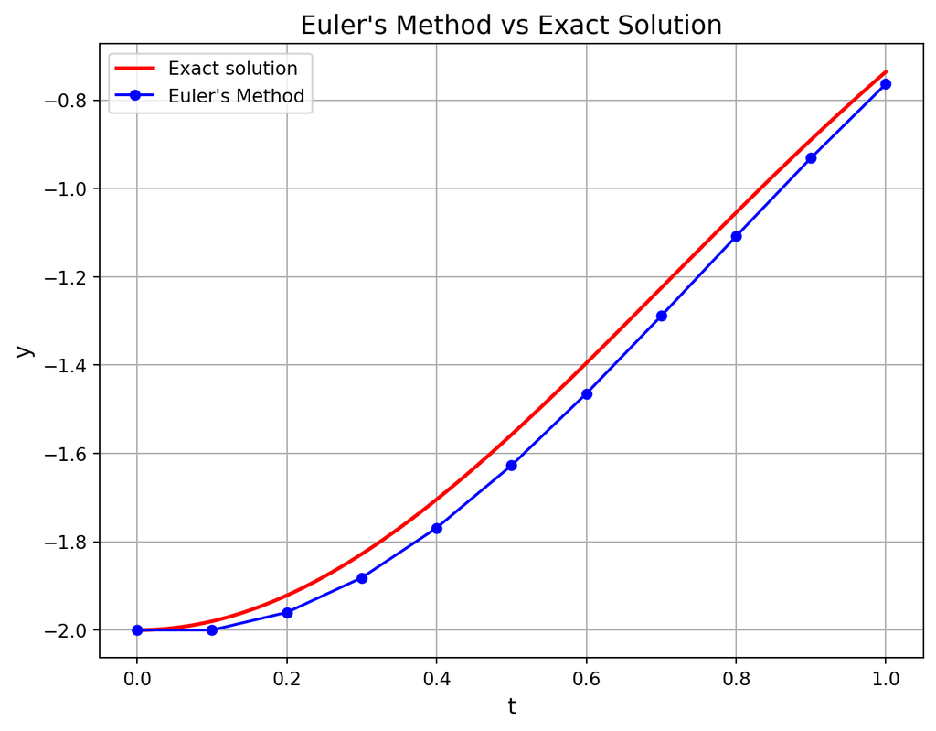

```python
t_vals_exact = np.linspace(0, 1, 200)
y_exact = exact_solution(t_vals_exact)

# Plot Euler's Method approximation and exact solution
plt.figure(figsize=(8, 6))
plt.plot(t_vals_exact, y_exact, 'r', label="Exact solution", linewidth=2)
plt.plot(t_vals_euler, y_euler, 'bo-', label="Euler's Method", markersize=5)

# Add labels, title, and legend
plt.title("Euler's Method vs Exact Solution", fontsize=14)
plt.xlabel("t", fontsize=12)
plt.ylabel("y", fontsize=12)
plt.grid(True)
plt.legend()

# Display the plot
plt.show()
```

**Final Answer:**

The **exact solution** to the differential equation is:

$$y = -2 e^{-t^2}$$

The graph compares Euler’s method with the exact solution. Euler’s method provides a reasonable approximation but slightly underestimates the true values as $t$ increases.

**2.6.7**

### Problem:

Solve the initial value problem using Euler’s method with $h = 0.1$ on the interval $[0, 1]$:

$$y' - y = 0, \quad y(0) = 2$$

In addition, find the exact solution and compare the values and plots of the approximate and exact solutions.

### Solution:

#### Exact Solution

The given equation is:

$$y' - y = 0$$

This is a separable differential equation. Rearrange it:

$$\frac{dy}{dt} = y$$

Separate the variables:

$$\frac{1}{y} \, dy = dt$$

Integrate both sides:

$$\int \frac{1}{y} \, dy = \int dt$$

$$\ln|y| = t + C$$

Exponentiate both sides to solve for $y$:

$$|y| = e^{t+C} = e^C \cdot e^t$$

Let $A = e^C$, so:

$$y = A e^t$$

Use the initial condition $y(0) = 2$ to find $A$:

$$2 = A e^0 \quad \Rightarrow \quad A = 2$$

The particular solution is:

$$y = 2 e^t$$

#### Euler’s Method

Euler’s method uses the formula:

$$y_{n+1} = y_n + h f(t_n, y_n)$$

where $f(t, y) = y$ (from the original equation $y' = y$).

Given:

- Step size $h = 0.1$
- Initial condition $y(0) = 2$
- Differential equation: $y' = y$

#### Comparison of approximate and exact solutions

##### Table

```python
# Step size and initial conditions
h = 0.1
t_vals_euler = np.arange(0, 1.1, h)
y_euler = np.zeros(len(t_vals_euler))
y_euler[0] = 2  # Initial condition y(0) = 2

# Define the differential equation y' = y
def f(t, y):
    return y

# Euler's method iteration
for i in range(1, len(t_vals_euler)):
    y_euler[i] = y_euler[i-1] + h * f(t_vals_euler[i-1], y_euler[i-1])

# Exact solution
def exact_solution(t):
    return 2 * np.exp(t)

# Exact solution values for comparison
t_vals_exact = np.linspace(0, 1, 200)
y_exact = exact_solution(t_vals_exact)

# Create a DataFrame for comparison
y_exact_small = exact_solution(t_vals_euler)
df_comparison = pd.DataFrame({
    't': t_vals_euler,
    'Euler Approximation': y_euler,
    'Exact Solution': y_exact_small
})

table_markdown = df_comparison.to_markdown(index=False)
# print(table_markdown)
```

| t | Euler Approximation | Exact Solution |
| --- | --- | --- |
| 0 | 2 | 2 |
| 0.1 | 2.2 | 2.21034 |
| 0.2 | 2.42 | 2.44281 |
| 0.3 | 2.662 | 2.69972 |
| 0.4 | 2.9282 | 2.98365 |
| 0.5 | 3.22102 | 3.29744 |
| 0.6 | 3.54312 | 3.64424 |
| 0.7 | 3.89743 | 4.02751 |
| 0.8 | 4.28718 | 4.45108 |
| 0.9 | 4.7159 | 4.91921 |
| 1 | 5.18748 | 5.43656 |

##### Graph:

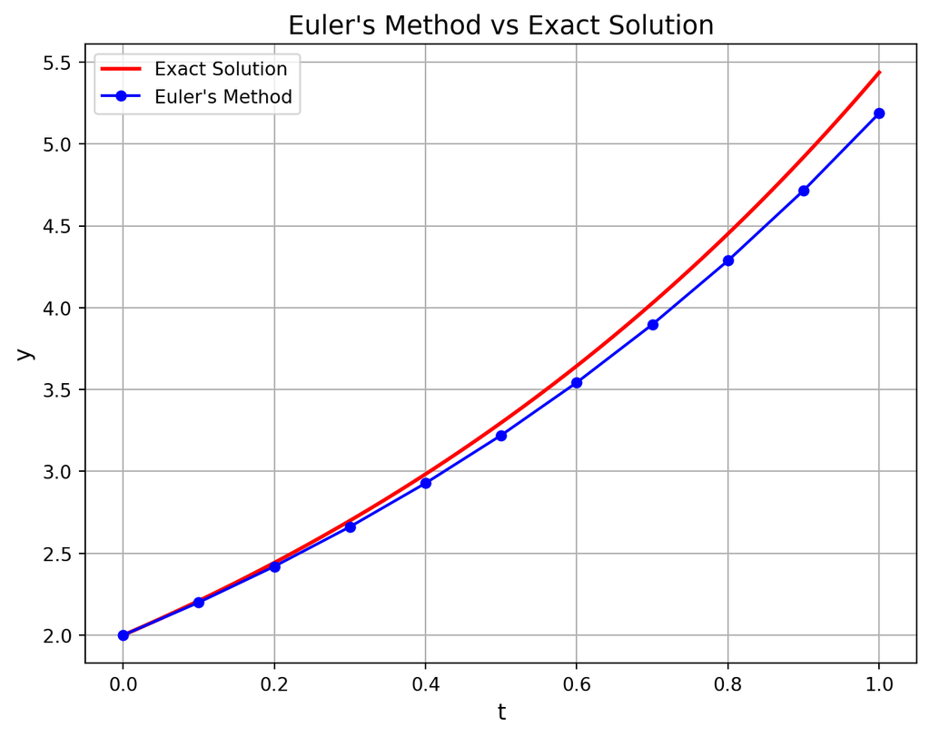

```python
# Plot Euler's Method approximation and exact solution
plt.figure(figsize=(8, 6))
plt.plot(t_vals_exact, y_exact, 'r', label="Exact Solution", linewidth=2)
plt.plot(t_vals_euler, y_euler, 'bo-', label="Euler's Method", markersize=5)

# Add labels, title, and legend
plt.title("Euler's Method vs Exact Solution", fontsize=14)
plt.xlabel("t", fontsize=12)
plt.ylabel("y", fontsize=12)
plt.grid(True)
plt.legend()

# Display the plot
plt.show()
```

**Final Answer:**

The **exact solution** to the differential equation is:

$$y = 2 e^t$$

The graph compares Euler’s method with the exact solution. Euler’s method provides a reasonable approximation but slightly underestimates the true values as $t$ increases.

**2.6.11**

### Problem:

Solve the initial value problem using Euler’s method with $h = 0.1$ on the interval $[0, 1]$:

$$(y')^2 - 2y^2 = t, \quad y(0) = 2$$

In addition, explain why it is not possible to solve the IVP exactly by established methods.

### Solution:

#### Rearrange the Differential Equation

We are given:

$$(y')^2 - 2y^2 = t$$

First, solve for $y'$:

$$(y')^2 = t + 2y^2$$

Taking the square root of both sides (assuming the positive root):

$$y' = \sqrt{t + 2y^2}$$

#### Euler’s Method

Euler’s method uses the formula:

$$y_{n+1} = y_n + h f(t_n, y_n)$$

where $f(t, y) = \sqrt{t + 2y^2}$, and the initial condition is $y(0) = 2$.

Given:

- Step size $h = 0.1$
- Initial condition $y(0) = 2$
- Differential equation: $y' = \sqrt{t + 2y^2}$

Calculate the approximate solution using Euler’s method.

#### Table

```python
h = 0.1
t_vals_euler = np.arange(0, 1.1, h)
y_euler = np.zeros(len(t_vals_euler))
y_euler[0] = 2  # Initial condition y(0) = 2

# Define the differential equation y' = sqrt(t + 2y^2)
def f(t, y):
    return np.sqrt(t + 2 * y**2)

# Euler's method iteration
for i in range(1, len(t_vals_euler)):
    y_euler[i] = y_euler[i-1] + h * f(t_vals_euler[i-1], y_euler[i-1])

# Create a DataFrame to display the Euler method approximation
df_euler_approximation = pd.DataFrame({
    't': t_vals_euler,
    'Euler Approximation': y_euler
})

table_markdown = df_euler_approximation.to_markdown(index=False)

# print(table_markdown)
```

| t | Euler Approximation |
| --- | --- |
| 0 | 2 |
| 0.1 | 2.28284 |
| 0.2 | 2.60723 |
| 0.3 | 2.97865 |
| 0.4 | 3.40344 |
| 0.5 | 3.8889 |
| 0.6 | 4.4434 |
| 0.7 | 5.07655 |
| 0.8 | 5.79934 |
| 0.9 | 6.62435 |
| 1 | 7.56597 |

#### Graph

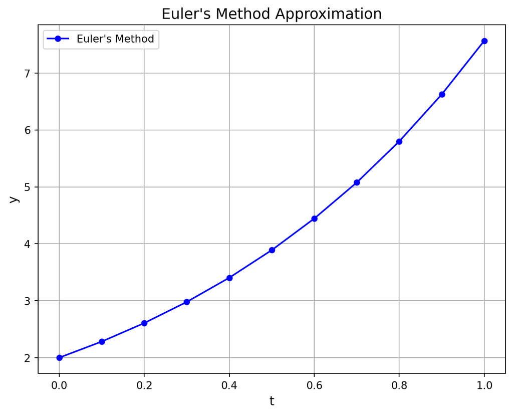

```python
plt.figure(figsize=(8, 6))
plt.plot(t_vals_euler, y_euler, 'bo-', label="Euler's Method", markersize=5)

# Add labels, title, and legend
plt.title("Euler's Method Approximation", fontsize=14)
plt.xlabel("t", fontsize=12)
plt.ylabel("y", fontsize=12)
plt.grid(True)
plt.legend()

# Display the plot
plt.show()
```

**Final Answer:**

The equation involves $(y')^2$, making it non-linear and not separable. As a result, standard methods like separation of variables or integrating factors cannot be applied, so numerical methods such as Euler’s method are needed to approximate the solution.

# SECTION 2.7

**Assigned:** 1, 3, 7**

**2.7.1**

### **Problem:**

For a population $P(t)$ that exhibits logistic growth according to the general model

$$\frac{dP}{dt} = kP \left(1 - \frac{P}{A}\right), \quad P(0) = P_0$$

where $k$ and $A$ are constants, solve the following:

1. Determine the values of $P$ (in terms of $A$ and $k$) for which $P$ is an increasing function.
2. Sketch by hand the direction field for the differential equation, clearly indicating the role of the constant $A$ in your sketch.
3. Determine the value(s) of $P$ (in terms of $A$ and $k$) for which $P$ is increasing most rapidly, and justify your answer.
4. Solve the initial-value problem explicitly for $P$ to show that

$$P(t) = \frac{A}{1 + Me^{-kt}}$$

and determine $M$ in terms of $A$ and $P_0$.

### **Solution:**

#### Part (a)

To determine when $P(t)$ is an increasing function, analyze the sign of $\frac{dP}{dt}$:

$$\frac{dP}{dt} = kP \left(1 - \frac{P}{A}\right)$$

Since $k$ is a positive constant, $\frac{dP}{dt}$ will be positive when $P \left(1 - \frac{P}{A}\right) > 0$.

1. $P > 0$ for population values (negative population is impossible).
2. The expression $1 - \frac{P}{A} > 0$ implies $P < A$.

So, $\frac{dP}{dt} > 0$ when $0 < P < A$. Therefore, $P(t)$ is increasing for $0 < P < A$.

#### Part (b)

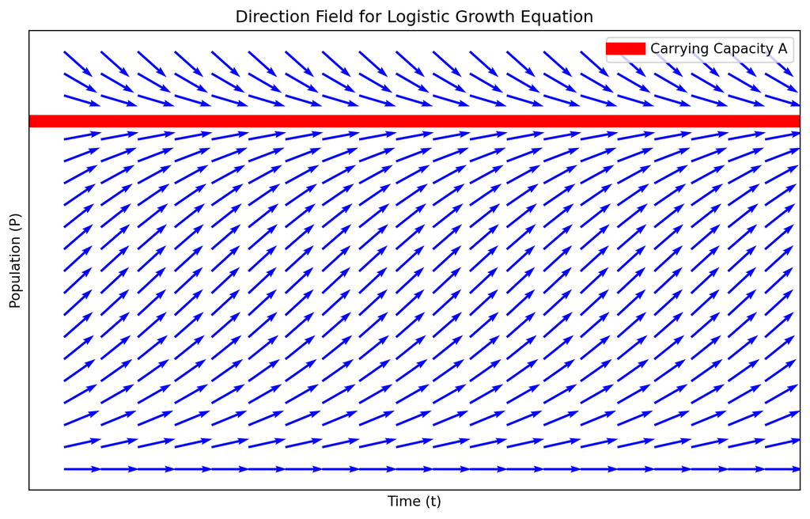

```python
import numpy as np
import matplotlib.pyplot as plt

# Constants
k = 0.75  # Growth rate constant
A = 100  # Carrying capacity


def dP_dt(P):
    return k * P * (1 - P / A)


P_values = np.linspace(0, 120, 20)
t_values = np.linspace(0, 10, 20)


P_grid, t_grid = np.meshgrid(P_values, t_values)
dP = dP_dt(P_grid)


norm = np.sqrt(1 + dP**2)
dt = 1 / norm
dP = dP / norm


plt.figure(figsize=(10, 6))
plt.quiver(t_grid, P_grid, dt, dP, angles='xy', scale=20, color="blue")
plt.axhline(A, color="red", linestyle="-", linewidth=9, label="Carrying Capacity A")

plt.xticks([])
plt.yticks([])


plt.xlabel("Time (t)")
plt.ylabel("Population (P)")
plt.title("Direction Field for Logistic Growth Equation")
plt.legend()
plt.grid(True)
plt.show()
```

#### Part (c)

To find the value of $P$ at which $P$ is increasing most rapidly take the derivative of $\frac{dP}{dt}$ with respect to $P$ and set it to zero:

1. Differentiate with respect to $P$:

   $$\frac{d}{dP}\left(kP \left(1 - \frac{P}{A}\right)\right) = k \left(1 - \frac{2P}{A}\right)$$
2. Set the derivative to zero to find the critical point:
   $$1 - \frac{2P}{A} = 0$$
   Solving for $P$:
   $$P = \frac{A}{2}$$

$P = \frac{A}{2}$ is the population level at which $P(t)$ is increasing most rapidly.

### Solution (with adjusted Step 4)

#### Part (d)

$$\frac{dP}{dt} = kP \left(1 - \frac{P}{A}\right)$$

1. **Separate variables:**

   $$\frac{1}{P \left(1 - \frac{P}{A}\right)} \, dP = k \, dt$$
2. **Rewrite the left side using partial fractions:**

   $$\frac{1}{P \left(1 - \frac{P}{A}\right)} = \frac{1}{P} + \frac{1}{A - P}$$

   $$\left( \frac{1}{P} + \frac{1}{A - P} \right) \, dP = k \, dt$$
3. **Integrate both sides:**

   $$\int \left( \frac{1}{P} + \frac{1}{A - P} \right) \, dP = \int k \, dt$$
4. **Solve the integrals and multiply by $-1$:**

   $$\ln |A - P| - \ln |P| = -kt - C$$
5. **Combine the logarithms:**

   $$\ln \left| \frac{A - P}{P} \right| = -kt - C$$
6. **Exponentiate both sides to solve for $P$:**

   $$\frac{A - P}{P} = e^{-kt - C} = M e^{-kt} \quad \text{(where $M = e^{-C}$)}$$
7. **Solve for $P$:**

   $$A - P = P \cdot M e^{-kt}$$

   Move terms involving $P$ to one side:

   $$P + P \cdot M e^{-kt} = A$$

   Factor out $P$:

   $$P (1 + M e^{-kt}) = A$$

   Solve for $P$:

   $$P = \frac{A}{1 + M e^{-kt}}$$
8. **Apply the initial condition $P(0) = P_0$ to determine $M$:**
   $$P_0 = \frac{A}{1 + M}$$
   Solving for $M$:
   $$M = \frac{A - P_0}{P_0}$$

The explicit solution is:

$$P(t) = \frac{A}{1 + \left(\frac{A - P_0}{P_0}\right)e^{-kt}}$$

where $A$ is the carrying capacity, $k$ is the growth rate constant, and $P_0$ is the initial population.

**Final Answer:**

- **(a)** $P(t)$ is an increasing function for $0 < P < A$.
- **(b)** The direction field shows arrows pointing upwards for $0 < P < A$, horizontal at $P = A$ (the carrying capacity), and downwards for $P > A$.
- **(c)** The value of $P$ at which $P$ is increasing most rapidly is $P = \frac{A}{2}$.
- **(d)** The explicit solution to the logistic growth equation is:
  $$P(t) = \frac{A}{1 + \left(\frac{A - P_0}{P_0}\right)e^{-kt}}$$
  where $A$ is the carrying capacity, $k$ is the growth rate constant, and $P_0$ is the initial population.

**2.7.3**

### **Problem:**

Consider the differential equation

$$\frac{dP}{dt} = -0.02 P^2 + 0.08 P$$

1. What are the equilibrium solutions to this equation?
2. Determine whether each equilibrium solution is stable or unstable.
3. At what value of $P$ is the function growing most rapidly?
4. Under the initial condition $P(0) = 0.25$, determine the time at which $P(t) = 3$.

### **Solution:**

#### Part (a)

To find the equilibrium solutions, set $\frac{dP}{dt} = 0$:

$$-0.02 P^2 + 0.08 P = 0$$

1. Factor out $P$:

   $$P \left(-0.02 P + 0.08\right) = 0$$
2. Set each factor to zero:
   - $P = 0$
   - $-0.02 P + 0.08 = 0$
3. Solve for $P$ in the second equation:
   $$-0.02 P = -0.08$$
   $$P = 4$$

The equilibrium solutions are $P = 0$ and $P = 4$.

#### Part (b)

To determine the stability of each equilibrium solution, examine the sign of $\frac{dP}{dt}$ around $P = 0$ and $P = 4$.

1. **For $P = 0$:**
   - When $P$ is slightly positive (just above 0), $\frac{dP}{dt} = -0.02 P^2 + 0.08 P$ is positive, which means $P$ increases.

   Therefore, $P = 0$ is **unstable**.
2. **For $P = 4$:**
   - When $P$ is slightly less than 4, $\frac{dP}{dt} = -0.02 P^2 + 0.08 P$ is positive, which means $P$ increases toward 4.
   - When $P$ is slightly more than 4, $\frac{dP}{dt}$ is negative, which means $P$ decreases toward 4.

   Therefore, $P = 4$ is **stable**.

#### Part (c)

1. Differentiate $\frac{dP}{dt}$ with respect to $P$:

   $$\frac{d}{dP} \left(-0.02 P^2 + 0.08 P\right) = -0.04 P + 0.08$$
2. Set the derivative to zero to find the critical point:
   $$-0.04 P + 0.08 = 0$$
   $$P = 2$$

$P(t)$ is growing most rapidly when $P = 2$.

#### Part (d)

To solve for the time $t$ when $P(t) = 3$ with the initial condition $P(0) = 0.25$, we start by solving the differential equation explicitly.

1. **Rewrite the differential equation:**

   $$\frac{dP}{dt} = -0.02 P^2 + 0.08 P$$

   Factor the right side:

   $$\frac{dP}{dt} = 0.02 P (4 - P)$$
2. **Separate variables:**

   $$\frac{1}{P (4 - P)} \, dP = 0.02 \, dt$$
3. **Use partial fraction decomposition on the left side:**

   $$\frac{1}{P (4 - P)} = \frac{1}{4} \left(\frac{1}{P} + \frac{1}{4 - P}\right)$$

   So the equation becomes:

   $$\frac{1}{4} \left(\frac{1}{P} + \frac{1}{4 - P}\right) \, dP = 0.02 \, dt$$
4. **Integrate both sides:**

   $$\int \frac{1}{4} \left(\frac{1}{P} + \frac{1}{4 - P}\right) \, dP = \int 0.02 \, dt$$

   $$\frac{1}{4} \left(\ln |P| - \ln |4 - P|\right) = 0.02 t + C$$
5. **Combine the logarithms:**

   $$\ln \left| \frac{P}{4 - P} \right| = 0.08 t + B$$

   where $B = 4C$ is a constant.
6. **Exponentiate both sides to solve for $P$:**

   $$\frac{P}{4 - P} = M e^{0.08 t}$$

   where $M = e^{B}$.
7. **Apply the initial condition $P(0) = 0.25$ to find $M$:**

   $$\frac{0.25}{4 - 0.25} = M$$

   $$M = \frac{0.25}{3.75} = \frac{1}{15}$$
8. **Solve for $t$ when $P(t) = 3$:**
   $$\frac{3}{4 - 3} = \frac{1}{15} e^{0.08 t}$$
   $$3 = \frac{1}{15} e^{0.08 t}$$
   $$e^{0.08 t} = 45$$
   $$0.08 t = \ln 45$$
   $$t = \frac{\ln 45}{0.08}$$

**Final Answer:**

- **(a)** The equilibrium solutions are $P = 0$ and $P = 4$.
- **(b)** The equilibrium $P = 0$ is unstable, and $P = 4$ is stable.
- **(c)** The function $P(t)$ is growing most rapidly when $P = 2$.
- **(d)** The time $t$ at which $P(t) = 3$ with the initial condition $P(0) = 0.25$ is:
  $$t = \frac{\ln 45}{0.08}$$

**2.7.7**

### **Problem:**

A cylindrical tank of height $4 \, \text{m}$ and radius $1 \, \text{m}$ is full of water. A small hole of diameter $1 \, \text{cm}$ is opened in the bottom of the tank. Use Torricelli’s law to determine how long it will take for all the water to drain from the tank.

### **Solution:**

**Torricelli’s Law:**

$$\frac{dV}{dt} = -a v = -a \sqrt{2gh}$$

Where:

- $V$ is the volume of water in the tank,
- $a$ is the cross-SECTIONal area of the hole,
- $v = \sqrt{2gh}$ is the velocity of the water leaving the hole,
- $g$ is the acceleration due to gravity ($9.8 \, \text{m/s}^2$),
- $h$ is the height of the water above the hole.

#### Define Areas

Let:

The volume $V$ of water in the tank is related to the height $h$ by $V = A_t h$.

$$\frac{dV}{dt} = A_t \frac{dh}{dt}$$

Substitute this into our initial equation:

$$A_t \frac{dh}{dt} = -a \sqrt{2gh}$$

#### Substitute Known Values

Substitute $A_t = \pi \, \text{m}^2$ and $a = 2.5 \times 10^{-5} \pi \, \text{m}^2$:

$$\pi \frac{dh}{dt} = -2.5 \times 10^{-5} \pi \sqrt{2gh}$$

Cancel $\pi$ from both sides:

$$\frac{dh}{dt} = -2.5 \times 10^{-5} \sqrt{2gh}$$

#### Separate Variables and Integrate

Rewrite the equation as:

$$\frac{dh}{\sqrt{h}} = -2.5 \times 10^{-5} \sqrt{2g} \, dt$$

Integrate both sides with respect to $h$ and $t$:

$$\int \frac{1}{\sqrt{h}} \, dh = -2.5 \times 10^{-5} \sqrt{2g} \int dt$$

$$2 \sqrt{h} = -2.5 \times 10^{-5} \sqrt{2g} \, t + C$$

#### Apply Initial Conditions

Initially, $h(0) = 4$ meters. Substitute $h = 4$ and $t = 0$ to solve for $C$:

$$2 \sqrt{4} = C$$

$$C = 4$$

So the equation becomes:

$$2 \sqrt{h} = -2.5 \times 10^{-5} \sqrt{2g} \, t + 4$$

#### Solve for $t$ when $h = 0$

When the tank is empty, $h = 0$. Substitute $h = 0$ into the equation:

$$2 \sqrt{0} = -2.5 \times 10^{-5} \sqrt{2g} \, t + 4$$

$$0 = -2.5 \times 10^{-5} \sqrt{2g} \, t + 4$$

$$2.5 \times 10^{-5} \sqrt{2g} \, t = 4$$

$$t = \frac{4}{2.5 \times 10^{-5} \sqrt{2g}}$$

#### Substitute $g = 9.8 \, \text{m/s}^2$ and Calculate $t$

$$t = \frac{4}{2.5 \times 10^{-5} \sqrt{2 \times 9.8}}$$

**Final Answer:**

The time required to drain the tank is:

$$t = \frac{4}{2.5 \times 10^{-5} \sqrt{2 \times 9.8}} \, \text{ seconds} \approx 10.04 \text{ hours}$$